# INFSCI 2595 Final Project

Part 4A, Interpretation - Features

Zhenyu Li

2022-04-24

```r
library(tidyverse)
theme_set(theme_linedraw())
library(tidymodels)
tidymodels_prefer()
library(vip)
source("./scripts/utils.R")
```

```r
df <- readr::read_csv("./data/final_project_train.csv", col_names = TRUE)
df_regr <- df %>% select(-c(rowid, outcome)) %>% mutate(response = log(response))
df_clas <- df %>% select(-c(rowid, response))
```

Tasks

- Identify the best model for the regression and classification tasks
- Identify the most important features/variables associated with best performing model for the regression and classification tasks
  - Are the most important variables similar for regression and classification tasks?
  - Does one of the sentiment derived feature types “dominate” the most important variables?
  - Does one of the sentiment derived feature types appear to be not helpful at all?
  - Does the formulation of the problem help with answer the questions
    - Based on your modeling results, do you feel these sentiment derived features are helpful at predicting the outputs?
    - Essentially, do you feel the model results are “good” and was I right about the relationship between report sentiment and the outputs?

## Best models

The best model for the **regression task** was identified in part 2D4 as the Elastic Net model.  
The best model for the **classification task** was identified in part 3D4 as the Elastic Net model.

**Read in the respective best model for each task.**

```r
mod_regr <- readr::read_rds("./models/mod_2D_enet_best_wflow")
mod_regr_fit <- mod_regr %>% fit(df_regr)

mod_clas <- readr::read_rds("./models/mod_3D_enet_best_wflow")
mod_clas_fit <- mod_clas %>% fit(df_clas)
```

## Feature Importance

**Plot the top 20 most important features for each model and discuss.**

### Regression

- For the regression model, since we are predicting time spent on sale, sentiment derived inputs that are associated with longer communications, or stronger responses from a customer (e.g. very positive, very negative), are expected to be important to predict the sale time.

**First examine all coefficients.**

[figure not shown]

```r
mod_regr_fit %>%
  extract_fit_parsnip() %>%
  vip(500, lambda = mod_regr$param$penalty) +
    ggtitle("regression: elastic net")
```

**Check the top 20 coefficients.**

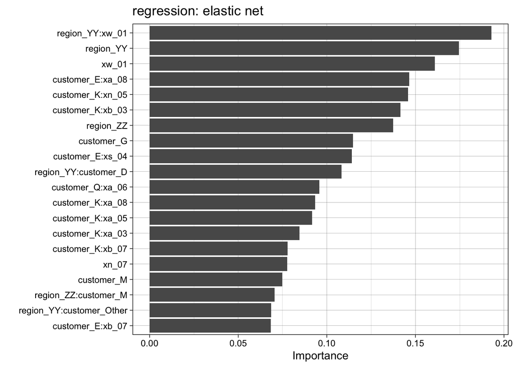

```r
mod_regr_fit %>%
  extract_fit_parsnip() %>%
  vip(20, lambda = mod_regr$param$penalty) +
    ggtitle("regression: elastic net")
```

- From my regression model:
  - The categorical input `region` appears to be an important predictor of conversation length.
  - Interaction of `customer` to some sentiment features are important.
    - For those sentiment features, we see `xa_`, `xb_`, `xw_` at high ranks.
    - It appears different lexicon derived features are important at predicting different customers.
  - For continuous input, word count derived feature `xw_01` is the most important.
  - Features from `xs_` set is rare in the top ranked inputs.

### Classification

- For the classification model, inputs that can reflect true intention of customer to purchase, or if a customer is interested in a product or not, could be more effective in predicting the `outcome` of a sale.

**First examine all coefficients.**

[figure not shown]

```r
mod_clas_fit %>%
  extract_fit_parsnip() %>%
  vip(500, lambda = mod_clas$param$penalty) +
    ggtitle("classification: elastic net")
```

**Check the top 20 coefficients.**

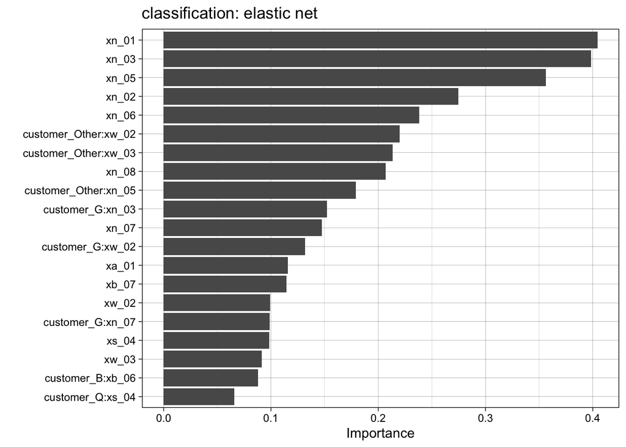

```r
mod_clas_fit %>%
  extract_fit_parsnip() %>%
  vip(20, lambda = mod_clas$param$penalty) +
    ggtitle("classification: elastic net")
```